# Problem Set 2: Election Fraud in Russia - Answers

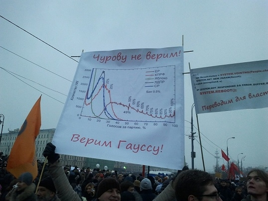

Protesters in the Aftermath of the 2011 State Duma Election.

The poster says, ‘We don’t believe Churov! We believe Gauss!’ Churov is the head of the State Electoral Commissions and Gauss refers to a 18th century German mathematician, Carl Friedrich Gauss, whom the Gaussian (Normal) distribution was named after. Source: http://darussophile.com/2011/12/measuring-churovs-beard/. [This source includes many additional analyses.]

In this exercise, we use the rules of probability to detect election fraud by examining voting patterns in the 2011 Russian State Duma election. (The State Duma is the federal legislature of Russia.) This exercise is based on:

Arturas Rozenas (2016). *Inferring Election Fraud from Distributions of Vote-Proportions.* Working Paper.

The ruling political party, United Russia, won this election, but faced many accusations of election fraud, which the Russian government denied. Some protesters highlighted irregular patterns of voting as evidence of election fraud, as shown in the Figure. In particular, protesters pointed out the relatively high frequency of common fractions such as $1/4$, $1/3$, and $1/2$ in the official vote shares.

We use official election results, contained in the object called `russia2011`, which comes in a data frame format and as a part of the `fraud.RData` file. Use the `russia2011` data to investigate whether there is any evidence for election fraud. Hint: the `fraud.RData` file can be loaded using the `load("data/filename.RData")` function. After the `load()` function you can use the `ls()` function to see which datasets were loaded in the R environment.

In addition to `russia2011`, the `fraud.RData` file contains election results from the 2003 Russian Duma election `russia2003`, the 2012 Russian presidential election `russia2012`, and the 2011 Canadian election `canada2011` as separate objects saved in data frame format. Each of these data sets has the same variables, described in the table below.

| Name | Description |
| --- | --- |
| `N` | Total number of voters in a precinct |
| `turnout` | Total number of turnout in a precinct |
| `votes` | Total number of votes for winner (United Russia) in a precinct |

## Answer 1

```r
load("data/fraud.RData")
ls() ## check what objects qxist in your workspace
```

```
## [1] "canada2011" "russia2003" "russia2011" "russia2012"
```

**For your information: first few observations of United Russia’s vote share as a proportion of the voters who turned out (variable `rvote`)**

```
## [1] 0.5797101 0.5745721 0.6919431 0.4135802 0.7099237 0.5970149
```

**Number of times different vote shares for United Russia occurred across precincts (10 most frequent occurring fractions**

```
##
##               0.5                 1 0.333333333333333               0.6
##               365               356               179               150
## 0.666666666666667               0.4 0.428571428571429              0.75
##               150               148               101                89
## 0.571428571428571 0.545454545454545
##                87                77
```

*Insert your answer here:*

(…)

**Histogram**

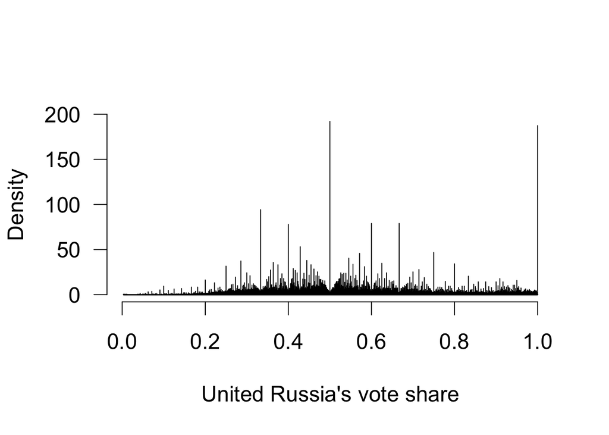

## Question 2 (40 points)

The mere existence of high frequencies at low fractions may not imply election fraud. Indeed, more numbers are divisible by smaller integers like 2, 3, and 4 than by larger integers like 22, 23, and 24. To investigate the possibility that the low fractions arose by chance (that they are very likely) you will be asked to do Monte Carlo Simulations. Do not worry we will guide you step by step through this process.

- *Note:*: Monte Carlo simulations refer to any probability simulation. (We will do/ did several in class.) We use simulations to estimate the possible outcomes of an uncertain event. For example, we can ask what is the probability of getting 4 women out of 5 senator draws from a distribution with 100 Senators: 74 men, 26 women. We can answer this question using an analytic solution. Alternatively, we can simulate random draws. This simulation process is referred to as Monte Carlo Simulation. There are many different Monte Carlo Methods.

Think about turnout and voting for the party United Russia (UR) *in a given precinct* as random variables. There is some underlying probability for both, turnout and UR vote in each precinct.

Let us assume that there is no electoral fraud and

- that the true probability of voting (turnout) in a given precinct is the observed turnout in the data for this precinct
- as well as that the true probability for voting for United Russia in a given precinct is the observed voting for United Russia for this precinct.

Given these assumptions (expected turnout rate is equal to observed turnout rate, expected UR vote share is equal to the observed UR vote share in each precinct) we can randomly draw turnout and vote shares from the underlying probability distributions in each precinct and count the number of times fractions with low numbers (1/2, 1/3, 2/3 etc.) occur.

More specifically, in this task we will be dealing with answering the following question: If the observed turnout and UR vote probability are the true probabilities, how probably is getting fractions with low numbers (1/2, 1/3, 2/3 etc. ) very frequently? In other words, if we take the observed probability of voting at elections and supporting United Russia in a given district as the true probability in this district, given the underlying probability distribution, what fractions of turnout and voting for United Russia would we get if we randomly draw 1000 of samples for each precinct? We will analyze this using simulations.

If we find that low fractions are highly likely to occur, then there is nothing striking that we observe in the elections data such high frequency of low fractions. If, however, we find that fractions with low numbers are highly unlikely, then the suggestion that there is no electoral fraud is not plausible.

**Let us phrase the above information in more formal terms:**

Assume the following probability model:

- **Assumption 1:** Turnout for a precinct is binomially distributed, with size equal to the number of voters in the precinct and success probability equal to its observed turnout rate.
  - Hint: remember that the binomial distribution describes the probability of having exactly *k* successes in *n* independent Bernouilli trials with probability of success *p*. For example, one flip of a coin is one Bernouilli trial and it takes a value of either 0 or 1. Let us now have 10 independent flips of a coin with probability of success (heads) p equal to 0.5. Every time we do 10 coin flips we will get a different number of heads. Therefore the random variable 10 flips of a coin can take any value from 0 to 10. The distribution of the number of successes (number of heads) from 10 coin flips with probability of head equal to 0.5 is one example of a binomial distribution (you can check how this specific binomial distribution loos like using the online applet here: (https://gallery.shinyapps.io/dist_calc/) .
  - Let us now get back to the question at hand. In this assignment it is assumed (it is given) that *turnout in **each** precinct* is a random variable which is binomially distributed. To know the exact distribution of the random variable `turnout` we need to know the number of independent trials and the probability of success (those who turnout) for each precinct. The assignment specifies that for the *number of independent trials* in each precinct we should take the *number of all registered voters* in this precinct. Further, the probability of turnout success (going to vote) in each precinct is equal to the observed turnout rate in the precinct at hand.
  - Let us take a concrete example of one precinct. Each row in the `russia2011` dataset contains information about the number of registered voters, turnout number and number of those who voted for United Russia for one precinct. (We do not have information what precinct this is. This information has been stripped off from the dataset.) For, example observation 1 (let’s call it precinct 1) has 179 registered voters (see code below).

```r
russia2011[1,]
```

```
##     N turnout votes     rvote
## 1 179     138    80 0.5797101
```

```r
set.seed(123456)
simulations <- rbinom(n = 10, size = 179, prob = 0.77)
simulations
```

```
##  [1] 133 132 141 129 138 135 137 134 156 129
```

Note that this is a random process, therefore each time you pass this code to the console you will get slightly different results (*If you want to get the same results you need to use the same seed (`set.seed()` function), see line 10 in the R code above). In the above code we save the results from the random draws in an object called `sumulations`. The results will range from 0 to 179, where 0 means when we drew 179 registered voters, 0 actually voted; 10, means that we got 10 voters out of 179 independently drawn registered voters and so on. In other words, each number in these results, e.g. 133 means, that given a random variable with 179 independent trials and probability of success 0.77, we got 133 successes. Here success means the person voted - 133 out of 179 people voted, hence a proportion of 0.7430168.

```
  - Simpler example: this is similar to the simulation we discussed in class where in a Senate with 100 people, 26 female and 74 male senators, we drew 5 senators and counted how many were female. Getting female senators is a random process, which follows a binomial distribution with 5 independent trials and success rate of 0.26. In other words, here the number of independent trials is 5 (5 independent draws), and the probability of success (drawing a woman) is 0.26. Now let us say you would like to do 30 simulations (30 times randomly drawing 5 senators, with replacement, since independent trials). For this purpose you would utilize the `rbinom()` function, and write
```

```r
set.seed(123456)
simulations <- rbinom(n = 30, size = 5, prob = 0.26)
simulations
```

```
##  [1] 2 2 1 1 1 0 1 0 4 0 2 1 3 2 4 3 2 0 1 2 0 0 0 0 1 2 2 2 2 0
```

In this example we saved in object `simulations` the results from each of the 30 simulations. The observations in the object `simulations` will range from 0 to 5, where 0 means when we drew 5 senators we got 0 women; 2, means that we got 2 women out of 5 independently drawn senators and so on. You will be expected to do the same for the turnout in each precinct.

**Now, let us move to the second central assumption we will make in this exercise.**

- **Assumption 2:** United Russia’s vote counts (how many people in the precinct vote for United Russia) in a precinct is binomially distributed with size (or independent trials) equal to the *number* of voters whom we *simulated to turn out* in the previous step and success probability equal to the precinct’s *observed* vote share for United Russia. Let us use a concrete example to illustrate this probability model:
- As a first step we need to calculate the simulated turnout rate for precinct 1. We will do only one simulation for illustration purposes.

```r
set.seed(123456)
one_sim_for_precinct1 <- rbinom(n = 1, size = 179, prob = 0.77)
one_sim_for_precinct1
```

```
## [1] 133
```

- The simulated turnout number in precinct 1 is 133 people. (The number will be different each time you run the above code, unless you use the same seed number). Now we have all information we need to represent the probability distribution of United Russia’s votes count in precinct 1
- As a second step we can draw random samples form this probability distribution and see how frequent are particular United Russia vote counts (e.g. how frequent is a 2/3, 1/3 etc.)
- The below code illustrates this step with 10 simulations

```r
set.seed(123456)
russia2011$votes[1]/russia2011$turnout[1] # the observed United Russia vote share in precinct 1
```

```
## [1] 0.5797101
```

```r
simulations <- rbinom(n = 10, size = one_sim_for_precinct1, prob = 0.579)
simulations
```

```
##  [1] 72 71 83 92 78 75 76 87 68 73
```

The interpretation of the simulations is similar to the one described about turnout above.

**Given the above 2 assumptions (Assumption 1 and Assumption 2)**:

1. Conduct a Monte Carlo simulation under the above 2 assumptions. *(20 points)*
2. 1000 simulated elections should be sufficient. (Be aware that this may be computationally intensive code. Write your code for a small number of simulations (5 or 10) for all exercises in this problem set to test before running all 1000 simulations! Do the 1000 simulations as the very last change to your script.)
3. What are the 10 most frequent United Russia’s vote share values? Discuss this in the text. *(10 points)*
4. Create a histogram of the simulated United Russia’s vote shares, similar to the one in the previous question. Comment on the results. *(10 points)*

To accomplish these tasks you can follow the below steps:

- create new variables for the observed turnout rate and the observed vote share for United Russia
  - create a new variable called `rturn` which specifies the turnout rate (percentage who voted) in each precinct.
  - you already created a variable `rvote` which specified the vote share for United Russia - the proportion of votes for United Russia from all those who actually voted.
- *for each precinct* (each observation in the dataset), run 1 simulation which calculates the turnout. (since there are 94995 precincts, you will have 94995 simulations). Then using these simulated turnout numbers (all 94995) simulate the vote share for United Russia in each precinct. REPEAT THESE TWO STEPS (simulate turnout and then UR Vote share for each precinct) 1000 times . You can use a loop which repeats these steps 1000 times. (Read further for more hints)
  - *Hint*. The `rbinom()` function is very flexible. Besides the examples from above where we always specified only one number for the independent trials (argument `size`), you can do simulations with different number of independent trials and probabilities in one go. For example. Let us say you want to do 10 simulations, where you are drawing different number of senators each time with a different probability of success. The code would look like this

```r
rbinom(n = 10, size = c(2,3,6,1,4,5,8,3,5,10), prob = c(0.26, 0.10, 0.55, 0.4, 0.3, 0.9, 0.6, 0.1, 0.35, 0.25 ))
```

```
##  [1] 1 0 1 1 2 4 6 1 3 2
```

This code does 10 simulations in total, each simulation with a different number of independent trials as specified in the argument `size` and a different probability of success as specified in the `prob` argument. In this example, the first simulation will have 2 independent trials and probability of success 0.26. The second simulation will have 3 independent trials and probability of success 0.10. The third simulation will have 6 number of trials and probability of success 0.55. And so on.

Why do we mention this? You can simulate turnout rates and then UR vote share for each of the 94995 precincts in one go! In a sense you will do 94995 simulations (1 for each precinct) in one go. (This will save you a lot of computational time).

- You are asked to repeat the 94995 precinct simulations 1000 times using a loop. At every iteration (or simulated election), you will have 94995 new UR vote share values - 1 for each precinct. You need to save them in a meaningful way. To achieve this you can combine the results from each of the 1000 iterations into a dataset using the function `cbind` (for columns bind) inside the loop.

Detailed guidelines: remember that the loop should loop over each of the 1000 simulated elections. In the first round of the loop you will get 94995 simulated United Russia votes - 1 for each precinct. In the second round of the loop you will get another 94995 simulated United Russia votes - 1 for each precinct and so on. Each time you need to save these somewhere.

- For this you need to create an empty object *outside* of the loop using the `c()` function. You can call it `final_vote_share`. E.g. `final_vote_share <- c()`. This object is empty (NULL) and can take any number of observations. You can then overwrite this object *inside* of the loop with its initial version and the added simulations using the `cbind()` function.
- After you are done with the 1000 repetitions (simulated elections), calculate how many times each vote share occurs across all precincts? Hint: you can use the `table` function here and sort the table output to go from highest number of cases to lowest (decreasing order). Show the 10 most frequent proportions, otherwise the table output might be too long. (*10 points*)
- make a histogram of the simulated vote shares. Discuss what you find. (*10 points*)
  - Is the relative frequency (or share) of small fractions such as 1/2, 1/3, and 2/3 high?
  - Do you observe a similar picture to what we found in the observed data of question 1 (roughly)?
  - Can you conclude that the high frequency of small fractions alone constitute evidence for election fraud? Elaborate why yes or why no.

## Answer 2

**First few observation in the variable `rturn`**

```
## [1] 0.7709497 0.6794020 0.6028571 0.5785714 0.8136646 0.6232558
```

**First few observation in the variable `rvote`**

```
## [1] 0.5797101 0.5745721 0.6919431 0.4135802 0.7099237 0.5970149
```

**dimensions of the `final_vote_share` object**:

If you followed the instructions above you will end up with 1000 repetitions. One loop round will produce 94995 simulations, which you will combine with the next round of calculations. In this way your object `final_vote_share` where you combined the 1000 iterations of 94995 simulations (1 for each precinct), each row is a given precinct, each column is a given repetition. In a sense you will simulate the `russia2011` data with the 94995 precincts 1000 times. You should thus have 94995 rows (or precinct) and 1000 columns (or simulations). (The loop will take about 2 minutes to run in the console)

**Number of rows and columns in the `final_vote_share` object**

```
## [1] 94995  1000
```

**First 5 precincts and first 10 simulations for each precinct from the `final_vote_share` object.**

For illustration reasons we also labeled the rows and columns, but you do not need to do this.

```
##            Simulation 1 Simulation 2 Simulation 3 Simulation 4 Simulation 5
## precinct 1    0.5352113    0.6567164    0.6056338    0.5839416    0.6285714
## precinct 2    0.5654321    0.5569307    0.6033654    0.6136364    0.5755396
## precinct 3    0.6779279    0.6892523    0.7028986    0.6643357    0.7123288
## precinct 4    0.4255319    0.4294671    0.3591331    0.3662420    0.3734940
## precinct 5    0.7122302    0.7338129    0.6715328    0.7183099    0.7463768
##            Simulation 6 Simulation 7 Simulation 8 Simulation 9 Simulation 10
## precinct 1    0.5514706    0.5899281    0.5611511    0.5486111     0.5774648
## precinct 2    0.5730858    0.5232274    0.5320197    0.5721154     0.5732323
## precinct 3    0.7166667    0.6836983    0.6855204    0.7178330     0.7121588
## precinct 4    0.4424242    0.4128440    0.4030769    0.4349112     0.3922156
## precinct 5    0.7421875    0.6910569    0.7265625    0.7080292     0.7076923
```

**10 most frequent proportions, decreasing from highest frequency** (Note that the exact number of proportions will vary from simulation to simulation. You might have slightly different results. This step might take about 2 minutes to show in the console)

```
## vote_share_final
##                 1               0.5 0.333333333333333 0.666666666666667
##            538687            346765            172963            154164
##               0.4               0.6 0.428571428571429 0.571428571428571
##            126467            118075             95792             90327
##              0.75 0.444444444444444
##             80217             76080
```

**Histogram of the simulated United Russia vote shares** (this can take about 30 seconds to plot)

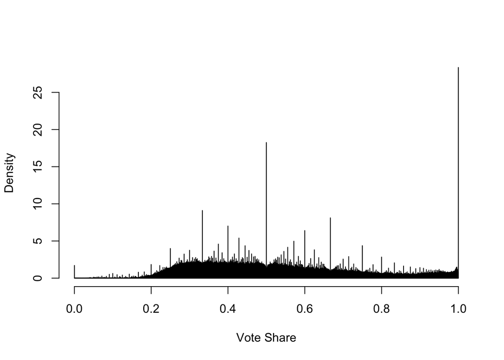

*Insert your answer here:*

(…)

## Question 3 (20 points)

To judge the Monte Carlo simulation results against the actual results of the 2011 Russian election, we will compare the *observed* frequency (in percentages) of a given fraction with its simulated counterpart.

The `vote_share_final` object has 94995 rows (precincts) and 1000 columns (simulations). In a sense, each column contains the results from one simulation of all precincts. Consequently we have 1000 simulated versions of the real voting results (94995 precincts, with simulated results 1000 times). **For each** of the 1000 simulated versions of the real data (*for each of the 1000 columns*), we can calculate the frequency of a given fraction (say the frequency of UR vote equal to exactly 1/3) and plot the 1000 frequencies. The frequency of a given fraction should not be in absolute numbers, but in percentages (number of times the fraction occurs/total number of cases) In such a way we can get 1000 frequencies of a given fraction and then plot the distribution of these frequencies. Finally, we can also indicate the observed frequency of this voting fraction (e.f. 1/3) from the `russia2011` dataset.

To achieve this follow the below steps:

- List for yourself the 6 most frequent fractions among all precincts (see question 2). From our simulation these were:
- Fraction $1/2$, which is equal to 0.5
- Fraction $1/3$, which is equal to 0.3333333
- Fraction $2/3$, which is equal to 0.6666667
- Fraction $2/5$, which is equal to 0.4
- Fraction $3/5$, which is equal to 0.6
- Fraction $3/7$, which is equal to 0.4285714
- create histograms showing the frequency distribution of each of these 6 fractions in separate plots. If your most frequent fractions from the simulated data are the above 6 ones, then show the frequency distribution for $1/2$, $1/3$, $2/3$, etc. (*10 points*)
  - to get the distribution for a given fraction, say $1/2$ you will need to count how many times $1/2$ occurs in each of the 1000 simulated elections. Recall that you did 1000 simulated elections, therefore you should have 1000 frequencies for the $1/2$ fraction. Similarly for the remaining fractions.
  - Example with fake data:
    - In the below code we create some numbers ranging from 0 to 100. These are arbitrary and serve only as an illustration

  ```r
      set.seed(123456)
      some_numbers <- seq(0, 100, by = 0.1)
      some_numbers[1:20] # show first 20 observations in our numbers
  ```

  ```
  ##  [1] 0.0 0.1 0.2 0.3 0.4 0.5 0.6 0.7 0.8 0.9 1.0 1.1 1.2 1.3 1.4 1.5 1.6 1.7 1.8
  ## [20] 1.9
  ```

  ```
  -   let us actually create a bigger dataset with the above numbers, by randomly sampling (do random draws with replacement) from the object `some_numbers` 1000 times.
  ```

  ```r
      set.seed(123456)
      fake_data<- sample(some_numbers, 1000, replace = T)
      length(fake_data) # fake data has 1000 observations
  ```

  ```
  ## [1] 1000
  ```

  ```r
      table(fake_data)[1:10] # we can see the frequency of the first 10 numbers in fake data by using the function table()
  ```

  ```
  ## fake_data
  ##   0 0.1 0.2 0.3 0.5 0.6 0.8   1 1.1 1.5
  ##   1   1   1   2   3   2   3   2   3   1
  ```

  ```
  -   Here we add 2 more columns with data to the initial `fake_data`
  ```

```r
## Create fake data with 3 columns
fake_data <- cbind(fake_data, fake_data-0.5, fake_data + 0.2)
colnames(fake_data) <- c("Column 1", "Column 2", "Column 3")
head(fake_data)
```

```
##      Column 1 Column 2 Column 3
## [1,]      5.9      5.4      6.1
## [2,]     23.3     22.8     23.5
## [3,]      4.1      3.6      4.3
## [4,]     88.0     87.5     88.2
## [5,]     12.5     12.0     12.7
## [6,]     71.0     70.5     71.2
```

```
- Now let us calculate the frequency of 1/2 in percentages considering all observations in the first column
```

```r
# we can first check for which observation the comparison is TRUE and then take the mean of the TRUE and FALSEs, which will yield the proportion of TRUE comparisons.
mean(fake_data[, 1] == 1/2)
```

```
## [1] 0.003
```

- to do the same for each columns you can use the `colMeans()` function.

```r
colMeans(fake_data == 1/2)
```

```
## Column 1 Column 2 Column 3
##    0.003    0.002    0.002
```

- Compare these frequency distributions with the fractions’ frequency from the *actual 2011_election*. Indicate the observed fraction frequency with a red vertical line. (*5 points*)
- Briefly interpret the your findings in the text. (*5 points*)

## Answer 3

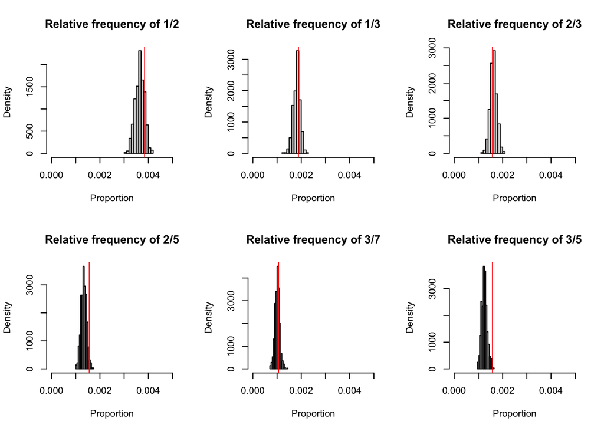

*Insert your answer here:*

(…)

## Question 4 (20 points + 20 Bonus)

Now, let us compare the relative frequency of observed fractions with the simulated ones beyond the six fractions examined in the previous question.

There are many different ways how to approach this task. You can use a loop, but you are not required to in this exercise. In fact, a loop would be rather inefficient. A much faster way is to utilize some of the properties of histograms. Recall, that histograms can show you the density or the frequency of observations within a given range - within a given bin. Let us use a fake example to illustrate this:

- Consider the fake data we created above.

```r
head(fake_data)
```

```
##      Column 1 Column 2 Column 3
## [1,]      5.9      5.4      6.1
## [2,]     23.3     22.8     23.5
## [3,]      4.1      3.6      4.3
## [4,]     88.0     87.5     88.2
## [5,]     12.5     12.0     12.7
## [6,]     71.0     70.5     71.2
```

- Let’s say your boss wants you to count the number of observations within a range of 2 points. This means:
  - How many observations do we have with numbers between [0 and 2) (0 including and 2 excluding)?
  - How many observations we have with numbers between [2 and 4)?
  - How many observations we have with numbers between [4 and 6), etc.?
- For this purpose we can utilize the properties of histograms
  - histograms help us visualize the distribution of numerical variables (like the ones we created above, not categories - you can recap the material on histograms in the QSS book, p. 81). Histograms can show either the density or the frequency of specific intervals (also referred to as bins). We can specify the range of the bins by setting the argument `breaks` to the desired intervals.
  - let us first create the intervals of interest, here we will make a sequence of numbers ranging from 0 to 100 in steps of 2, because later on we will be counting the number of observations between 0 and 2, between 2 and 4 and so on.

```r
intervals_of_interest <- seq(0,100, by = 2)
intervals_of_interest
```

```
##  [1]   0   2   4   6   8  10  12  14  16  18  20  22  24  26  28  30  32  34  36
## [20]  38  40  42  44  46  48  50  52  54  56  58  60  62  64  66  68  70  72  74
## [39]  76  78  80  82  84  86  88  90  92  94  96  98 100
```

- Let us now plot the fake data we created by setting the `breaks` argument to the intervals of interest.
- Note that we will also assign the histogram to an object called `res` for later usage.

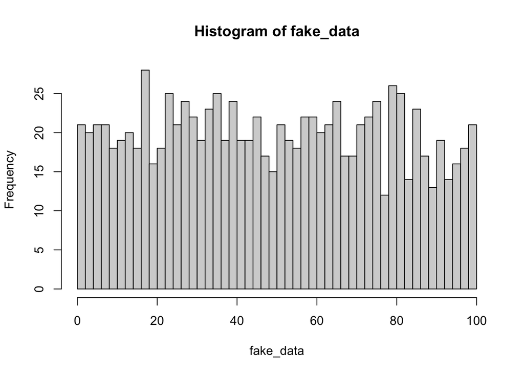

```r
fake_data <- fake_data[,1] # we keep only one column for illustration reasons
res <- hist(fake_data, plot = T, # if you do not want to see the plot you can set the argument plot = FALSE
            breaks = intervals_of_interest,
            right = F) # specifies whether the right number of the interval should be included (right = TRUE) or excluded (right = FALSE)
```

- Let’s see what we saved in the `res` object. Quite a lot of information including
  - the breaks, which specify the interval for each bin to be plotted
  - the counts, which give you the frequency of observations within a given interval
  - the exact density etc.

  ```r
  res
  ```

  ```
  ## $breaks
  ##  [1]   0   2   4   6   8  10  12  14  16  18  20  22  24  26  28  30  32  34  36
  ## [20]  38  40  42  44  46  48  50  52  54  56  58  60  62  64  66  68  70  72  74
  ## [39]  76  78  80  82  84  86  88  90  92  94  96  98 100
  ##
  ## $counts
  ##  [1] 21 20 21 21 18 19 20 18 28 16 18 25 21 24 22 19 23 25 19 24 19 19 22 17 15
  ## [26] 21 19 18 22 22 20 21 24 17 17 21 22 24 12 26 25 14 23 17 13 19 14 16 18 21
  ##
  ## $density
  ##  [1] 0.0105 0.0100 0.0105 0.0105 0.0090 0.0095 0.0100 0.0090 0.0140 0.0080
  ## [11] 0.0090 0.0125 0.0105 0.0120 0.0110 0.0095 0.0115 0.0125 0.0095 0.0120
  ## [21] 0.0095 0.0095 0.0110 0.0085 0.0075 0.0105 0.0095 0.0090 0.0110 0.0110
  ## [31] 0.0100 0.0105 0.0120 0.0085 0.0085 0.0105 0.0110 0.0120 0.0060 0.0130
  ## [41] 0.0125 0.0070 0.0115 0.0085 0.0065 0.0095 0.0070 0.0080 0.0090 0.0105
  ##
  ## $mids
  ##  [1]  1  3  5  7  9 11 13 15 17 19 21 23 25 27 29 31 33 35 37 39 41 43 45 47 49
  ## [26] 51 53 55 57 59 61 63 65 67 69 71 73 75 77 79 81 83 85 87 89 91 93 95 97 99
  ##
  ## $xname
  ## [1] "fake_data"
  ##
  ## $equidist
  ## [1] TRUE
  ##
  ## attr(,"class")
  ## [1] "histogram"
  ```

- We need the counts. We can access them using the `$` operator:

```r
res$counts
```

```
##  [1] 21 20 21 21 18 19 20 18 28 16 18 25 21 24 22 19 23 25 19 24 19 19 22 17 15
## [26] 21 19 18 22 22 20 21 24 17 17 21 22 24 12 26 25 14 23 17 13 19 14 16 18 21
```

- How can we interpret these numbers?
  - the first number 21 gives you the frequency of observations for the first interval which ranges from 0 to 2 [including 0, excluding 2). In other words we have 21 observations with numbers between 0 and 2.
  - the second number in `res$counts` 20 gives you the frequency of observations which fall within the interval 2 to 4 and so on.
  - We can see all intervals by calling `res$breaks`

  ```r
  res$breaks
  ```

  ```
  ##  [1]   0   2   4   6   8  10  12  14  16  18  20  22  24  26  28  30  32  34  36
  ## [20]  38  40  42  44  46  48  50  52  54  56  58  60  62  64  66  68  70  72  74
  ## [39]  76  78  80  82  84  86  88  90  92  94  96  98 100
  ```

Now, let us return to the task for this exercise. Follow the below steps to accomplish it:

1. create intervals between 0 and 1 (the last interval should be 1) in steps of 0.01. You will use these intervals to create bin sizes of 0.01. One bin will range from 0 to 0.01 (0 including, 0.01 excluding), the next been from 0.01 to 0.02 (0.01 including, 0.02 excluding), the next from 0.02 to 0.03 etc. *(2 points)*
2. In this step focus on the *observed data* - `russia2011` and compute the number of observations (UR vote shares) that fall into each bin of 0.01 in the `russia2011` data. This means you are asked to compute in how many precincts do we find a vote share between 0 and 0.01 (including 0, but excluding 0.01) for UR, the same for vote shares between 0.01 and 0.02 (including 0.01 but excluding 0.02) etc. Note that the right number of each interval (bin), should be excluded. *(10 points)*
3. Using the number of of observations that fall within each bin, calculate the *proportion* of observations that fall within each bin of 0.01. In essence, here we want to know what percentage of precincts (from a total of 94995) have UR vote share which are between 0 and 0.01, between 0.01 and 0.02 and so on. *(3 points)*
4. In this step you are asked to repeat step 2 and 3 for the simulated data - hence 1000 times. *(10 points)* Recall that your simulated data has 94995 rows (or precincts), and 1000 columns (or simulations). This in practice means that you have 1000 simulated versions of the `russia2011` data, or 1000 simulated elections. To repeat step 2 and 3 (calculate the number and then proportions of observations with UR vote shares falling within given bin of size 0.01) 1000 times you can utilize a loop. Again, this would be rather inefficient and time costly. Instead, you can create a function which does step 2 and 3 and then apply this function to each *column* (each simulation) in your simulated data. Hint: the `apply()` function allows you to apply a function by rows or columns. We will guide you through this process.
- create a function that does step 2 and 3. You can recap how to do functions in the QSS book, p. 19. You can find some good examples for simple functions here: https://swcarpentry.github.io/r-novice-inflammation/02-func-R/
  - the function will run a histogram with bins ranging from 0 to 1 (*including 1*) in steps of 0.01
  - save the counts for each interval
  - turn these counts into percentages
  - return the percentages. Hint, remember to include `return(your_results)` inside of your function.
  - given the above steps, the only thing that varies when you want to perform steps 2 and 3 is the data (observed data, simulation 1, simulation 2, … simulation 1000). Therefore, you will need only one argument for this function. You can call it `my_data`.
  - here is a simple example of a function (taken from https://swcarpentry.github.io/r-novice-inflammation/02-func-R/), which has one argument and returns the results.

```r
## convert Fahrenheit to Celsius
fahrenheit_to_celsius <- function(temp_F) { # temp_F is your argument, which we will use inside the function. later when we call the function, we will set the argument temp_F to be equal to specific temperatures measures in Fahrenheit
  temp_C <- (temp_F - 32) * 5 / 9 # here we use the formula to transform Fahrenheit into Celsius and save the result in object temp_C inside the function
  return(temp_C) # this line is very important, it says, please return or show us what is in temp_C. Without return the transformation from Fahrenheit to Celsius will be only saved in an internal to the function object temp_C, hence will exist inside of the function, and will be saved in the background, but will it will not be possible to access it.
}

fahrenheit_to_celsius(temp_F = 100) # here we set the argument temp_F to 32, the function performs all calculations inside the function using temp_F = 100. At the end it shows us the result.
```

```
## [1] 37.77778
```

```r
fahrenheit_to_celsius(temp_F = 32) # here we set the argument temp_F to 32
```

```
## [1] 0
```

- Here is an example how to use the `apply()` function. It is fairly similar to the `tapply()` function, which as you recall applies a function by different categories of another variable. Instead of applying the function by categories, the `apply()` function allows you to apply a given function by rows or columns. Let us take a simple example, where we would like to to take the mean of each row in the `russia2011` data.

```r
res<-apply(X = russia2011, MARGIN = 1, FUN = mean) # if you would like to calculate the average value by columns, set MARGIN = 2.
length(res)
```

```
## [1] 94995
```

```r
res[1:10]
```

```
##          1          2          3          4          5          6          7
##   79.67013  249.45079  283.05896  203.79843   77.30472   86.04405 1083.08736
##          8          9         10
##  471.98812   87.39437  563.61494
```

The apply function takes three main arguments. The argument X specified the dataset (with rows and columns) on which you will be applying the function. The argument MARGIN, specifies whether you want to apply the function by rows or columns, where 1 means rows, and 2 means columns. The argument FUN specifies which function should be applied by row or column. In our below example we want to calculate the mean value for each row in the `russia2011` dataset. We save the results from the apply function in an object `res`. The first observation in object `res`, has a value of 79.670132, which is the mean/average of all variables ( 179, 138, 80, 0.5797101, 0.7709497) for the first observation or the first row in `russia2011`. 249.4507948 gives us the average of all variables for the second row in `russia2011` and so on.

Let us calculate the average value by columns and save the results in an object called `res`.

```r
res<-apply(X = russia2011, MARGIN = 2, FUN = mean)
length(res)
```

```
## [1] 5
```

```r
res
```

```
##            N      turnout        votes        rvote        rturn
## 1146.5605979  678.3370493  339.7935154    0.5194969    0.6475034
```

Given that we applied the `mean()` function by columns, the `res` object will have 5 observations, the average value for each of the 5 variables - the average value of `turnout` 678.3370493, the average value of `votes` 339.7935154, … the average value of `rturn` 0.6475034.

…Now lets get back to the exercise

5. After you repeated step 2 and step 3 for the 1000 simulated elections (or for every of the 1000 columns in the simulated data), examine whether or not the observed proportion (from `russia2011` data) falls within the 2.5 and 97.5 percentiles of the corresponding simulated proportions. To do so follow the below steps:
- calculate the 2.5 and 97.5 percentiles of the frequencies of UR vote shares falling within each interval of 0.01. For example for the interval [0, 0.01] you will have 1000 numbers, which indicate how many UR vote shares fall within this interval. You will have 1000 frequencies for this interval, because you have 1000 simulations. What you are asked is to calculate the 2.5 and the 97.5 percentile from these 1000 frequencies for each interval. Hint: you can use the function `percentile()`. The idea is to show the distribution of these frequencies for each interval in a meaningful way - the middle 95% of all simulated frequencies and then check whether the observed frequency of United Russia vote shares between 0 and 0.01 falls inside the middle 95% or outside of it. *(5 points)*
- Plot the result with vote share bins on the horizontal axis and the percentage of times these vote shares occurred on the vertical axis. Use blue dots for the observed vote shares and their frequencies. Use lines for the 2.5th and 95th percentiles from the simulated data. This plot attempts to reproduce the one held by protesters in the figure. *(5 points)*
- As a next step count the number of times an observed precinct vote share (the blue dots) falls outside its simulated 95% interval. Hint: when the observed frequencies for each 0.01 interval are smaller than the 2.5th and bigger than the 95th percentiles from the simulated data. Interpret the results. *(5 points)*

## Answer 4

**desired intervals**

```
##   [1] 0.00 0.01 0.02 0.03 0.04 0.05 0.06 0.07 0.08 0.09 0.10 0.11 0.12 0.13 0.14
##  [16] 0.15 0.16 0.17 0.18 0.19 0.20 0.21 0.22 0.23 0.24 0.25 0.26 0.27 0.28 0.29
##  [31] 0.30 0.31 0.32 0.33 0.34 0.35 0.36 0.37 0.38 0.39 0.40 0.41 0.42 0.43 0.44
##  [46] 0.45 0.46 0.47 0.48 0.49 0.50 0.51 0.52 0.53 0.54 0.55 0.56 0.57 0.58 0.59
##  [61] 0.60 0.61 0.62 0.63 0.64 0.65 0.66 0.67 0.68 0.69 0.70 0.71 0.72 0.73 0.74
##  [76] 0.75 0.76 0.77 0.78 0.79 0.80 0.81 0.82 0.83 0.84 0.85 0.86 0.87 0.88 0.89
##  [91] 0.90 0.91 0.92 0.93 0.94 0.95 0.96 0.97 0.98 0.99
```

**Create the function**

**Observed frequency of UR vote shares for each 0.01 interval: shares for the first few intervals out of a total of 100 intervals**

Hint: this calculations are done on the observed data, therefore you should have the same numbers.

```
##            0         0.01         0.02         0.03         0.04         0.05
## 4.210748e-05 1.052687e-05 0.000000e+00 2.105374e-05 4.210748e-05 8.421496e-05
```

**Frequencies of simulated UR vote shares for each interval of 0.01.**

**For your information: the dimensions of the results**

```
## [1]  100 1000
```

**For your information: show the frequencies for the first 7 intervals and 4 simulations**

```
##      Simulation 1 Simulation 2 Simulation 3 Simulation 4
## 0    3.684404e-04 3.158061e-04 3.368598e-04 4.105479e-04
## 0.01 0.000000e+00 2.105374e-05 1.052687e-05 1.052687e-05
## 0.02 1.052687e-05 1.052687e-05 0.000000e+00 1.052687e-05
## 0.03 5.263435e-05 3.158061e-05 1.052687e-05 5.263435e-05
## 0.04 1.052687e-05 6.316122e-05 6.316122e-05 1.052687e-04
## 0.05 1.263224e-04 1.157956e-04 1.157956e-04 8.421496e-05
## 0.06 8.421496e-05 1.052687e-04 1.579030e-04 1.052687e-04
```

**Compute 95% intervals for each bin proportion (hence by row)**

**For your information: 2.5% and 95% for the first 7 bins**

```
##                  0         0.01         0.02         0.03         0.04
## 2.5%  0.0002736986 0.000000e+00 0.000000e+00 1.052687e-05 2.105374e-05
## 97.5% 0.0004737091 3.158061e-05 3.158061e-05 8.421496e-05 1.157956e-04
##               0.05         0.06
## 2.5%  5.263435e-05 3.158061e-05
## 97.5% 1.789568e-04 1.368493e-04
```

**Plot**

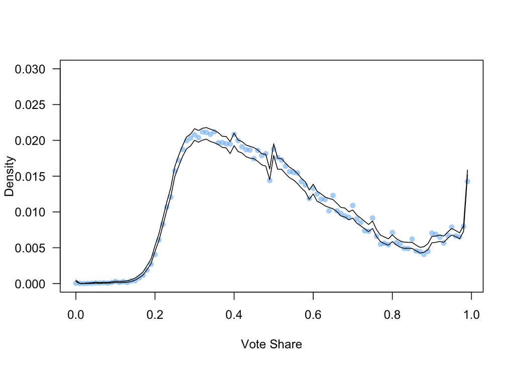

**Number of times observed proportions are outside the simulated 95% interval**

```
## [1] 31
```

*Insert your answer here*

(…)

## Question 5 (Bonus question for 20 points)

- To put the results of the previous question in perspective, apply the procedure developed in the previous question to the 2011 Canadian elections and the 2003 Russian election, where no major voting irregularities were reported. *(10 points)*
  - You can copy and paste the above code and run it using these datasets. Alternatively, you can (but are not required to) write a function which runs all above steps and run the function using different datasets.
- In addition, apply this procedure to the 2012 Russian presidential election, where election fraud allegations were reported. *(5 points)*
- No plot needs to be produced.
- Briefly comment on the results you obtain. *(5 points)*

Hint: instead of using a loop to simulate 1000 times the election data, you can try using the `replicate()` function (not `rep()` function). The `replicate()` function allows you to repeat the application of a function as many times as you want. It is very useful for repeating simulations. For example:

Let us do 10 simulations where we draw 5 senators and check how many are female. Getting female senators is a random process, which follows a binomial distribution with 5 independent trials and success rate of 0.26. We did this in the above examples using the `rbinom()` function. Now your boss wants you to repeat these 10 simulations 15 times. What you can do is first write a function which does the 10 simulations with the specifications at hand. Then use the `replicate()` function to run the function 15 times.

**Create a function which does the simulations**

```r
## create a function which does 10 simulations - 10 times drawing  5 senators with probability of success 0.26
my.function <- function(){ # note that this function has no pre-defined argument
  rbinom(n = 10, size = 5 , prob = 0.26 )
}
```

**Call the function**

```r
my.function() # call the function. Since this function has no predefined arguments we leave the round brackets () empty.
```

```
##  [1] 1 0 2 1 3 1 1 0 3 1
```

**Repeat the function 15 times and save the results in an object**

```r
res <- replicate(n = 15, expr =  my.function())
res ## rows are the individual simulations (10), columns are the 15 repetitions of these 10 simulations
```

```
##       [,1] [,2] [,3] [,4] [,5] [,6] [,7] [,8] [,9] [,10] [,11] [,12] [,13]
##  [1,]    2    2    2    0    0    3    2    0    2     3     1     3     1
##  [2,]    1    0    3    1    1    1    1    2    2     0     1     1     1
##  [3,]    2    0    3    1    1    0    1    1    3     1     2     3     3
##  [4,]    0    1    0    0    2    2    1    1    3     0     1     1     1
##  [5,]    2    2    0    3    2    3    2    2    1     1     2     2     0
##  [6,]    1    3    1    1    4    1    0    3    0     0     1     3     3
##  [7,]    1    0    1    1    0    1    3    0    1     0     2     0     2
##  [8,]    1    1    3    1    2    4    0    2    1     2     1     2     0
##  [9,]    2    3    1    0    1    2    1    2    1     1     0     2     1
## [10,]    2    2    2    0    2    2    3    1    0     3     2     0     2
##       [,14] [,15]
##  [1,]     1     1
##  [2,]     2     1
##  [3,]     2     2
##  [4,]     2     0
##  [5,]     3     1
##  [6,]     0     2
##  [7,]     2     1
##  [8,]     0     1
##  [9,]     1     1
## [10,]     1     2
```

You can find further useful examples here: https://www.statology.org/replicate-function-in-r/

Note: This question requires computationally intensive code. Write a code with a small number of simulations first and then run the final code with 1000 simulations. The below results are just an example. Every time you will run the simulations a new, you will get slightly different numbers.

## Answer 5

Since we repeat the same analysis using different data sets, we create a function that implements the analysis.

**Number of times the observed frequency exceeds the [2.5% and 97.5%] range of the simulated frequency in the:**

**Canadian 2011 elections: number of times observed proportions are outside the simulated 95% interval**

```
## [1] 18
```

**Russian 2003 elections: number of times observed proportions are outside the simulated 95% interval**

```
## [1] 22
```

**Russian 2012 elections: number of times observed proportions are outside the simulated 95% interval**

```
## [1] 24
```

**Russian 2011 elections: number of times observed proportions are outside the simulated 95% interval**

[output not shown]

*Insert your answer here:* (…)

## Evaluation

- 4 questions for a total of 100 points
- 1 bonus question for a total of 40 points (split between question 4 and question 5)